# Analise Porta dos Fundos Adaptado Basic Text Mining in R

# Word Frequency

There are a lot of terms, so for now, just check out some of the most and least frequently occurring words.

```r
freq[head(ord)]
```

```
## aaaaaeeeee     aaaaaf   aaaaafdx     abaixa  abaixando     abaixo
##          1          1          1          1          1          1
```

```r
freq[tail(ord)]
```

```
##   coca  merda kellen  vídeo   nome   kkkk
##    494    688    712    787   2327   2792
```

```r
head(table(freq), 20)
```

```
## freq
##    1    2    3    4    5    6    7    8    9   10   11   12   13   14   15
## 5914 1222  542  379  226  155  125   80   66   53   51   39   31   33   39
##   16   17   18   19   20
##   25   29   10   16   17
```

```r
tail(table(freq), 20)
```

```
## freq
##  170  172  173  179  185  212  241  262  270  280  347  365  386  467  494
##    1    1    1    1    1    1    1    1    1    1    1    1    1    1    1
##  688  712  787 2327 2792
##    1    1    1    1    1
```

Considering only the 20 greatest frequencies, we can see that there is a huge disparity in how frequently some terms appear.

For a less, fine-grained look at term freqency we can view a table of the terms we selected when we removed sparse terms, above. (Look just under the word “Focus”.)

```r
freq <- colSums(as.matrix(dtms))
#freq
```

The above matrix was created using a data transformation we made earlier. What follows is an alternative that will accomplish essentially the same thing.

```r
freq <- sort(colSums(as.matrix(dtms)), decreasing=TRUE)
head(freq, 14)
```

```
##    kkkk    nome   vídeo  kellen   merda    coca    puta    kkkk   dolly
##    2792    2327     787     712     688     494     467     386     365
##   canal    cara pessoas   achei  melhor
##     347     280     270     262     241
```

```r
findFreqTerms(dtm, lowfreq=150)   # Change "150" to whatever is most appropriate for your text data.
```

```
##  [1] "achei"     "acho"      "agora"     "canal"     "cara"
##  [6] "coca"      "derivação" "desse"     "dolly"     "humor"
## [11] "kelen"     "kellen"    "kkkk"      "kkkk"      "melhor"
## [16] "merda"     "nome"      "nomes"     "nunca"     "pessoas"
## [21] "porta"     "puta"      "ruim"      "vídeo"
```

Yet another way to do this:

```r
wf <- data.frame(word=names(freq), freq=freq)
head(wf)
```

```
##          word freq
## kkkk     kkkk 2792
## nome     nome 2327
## vídeo   vídeo  787
## kellen kellen  712
## merda   merda  688
## coca     coca  494
```

Plot Word Frequencies Plot words that appear at least 150 times.

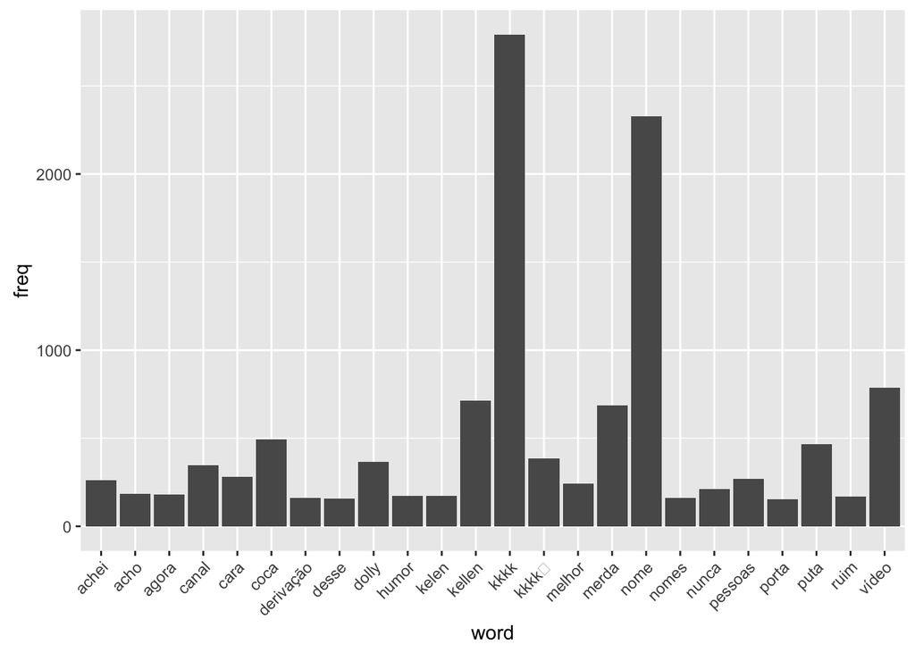

```r
library(ggplot2)
p <- ggplot(subset(wf, freq>150), aes(word, freq))
p <- p + geom_bar(stat="identity")
p <- p + theme(axis.text.x=element_text(angle=45, hjust=1))
p
```

# Relationships Between Terms

Term Correlations If you have a term in mind that you have found to be particularly meaningful to your analysis, then you may find it helpful to identify the words that most highly correlate with that term.

If words always appear together, then correlation=1.0.

```r
findAssocs(dtms, c("nome"), corlimit=0.98) # specifying a correlation limit of 0.98
```

```
## $nome
## numeric(0)
```

```r
findAssocs(dtms, "contrast", corlimit=0.95) # specifying a correlation limit of 0.95
```

```
## $contrast
## numeric(0)
```

# Word Clouds!

Humans are generally strong at visual analytics. That is part of the reason that these have become so popular. What follows are a variety of alternatives for constructing word clouds with your text.

But first you will need to load the package that makes word clouds in R.

```r
library(wordcloud)
```

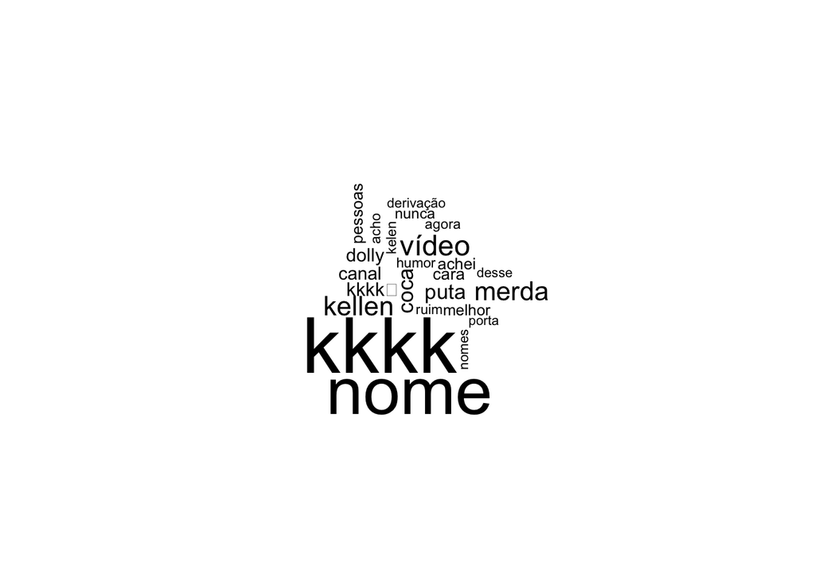

```r
set.seed(142)
wordcloud(names(freq), freq, min.freq=150)
```

Note: The “set.seed() function just makes the configuration of the layout of the clouds consistent each time you plot them. You can omit that part if you are not concerned with preserving a particular layout.

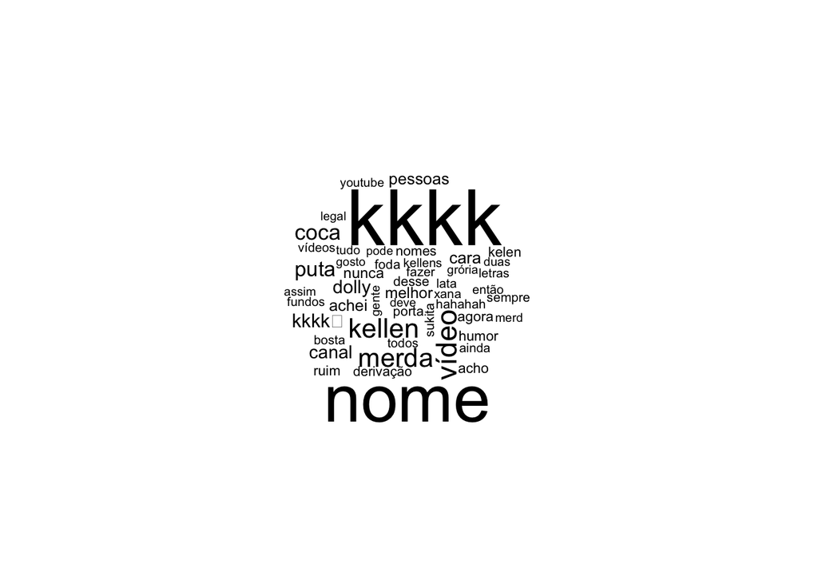

```r
set.seed(142)
wordcloud(names(freq), freq, max.words=50)
```

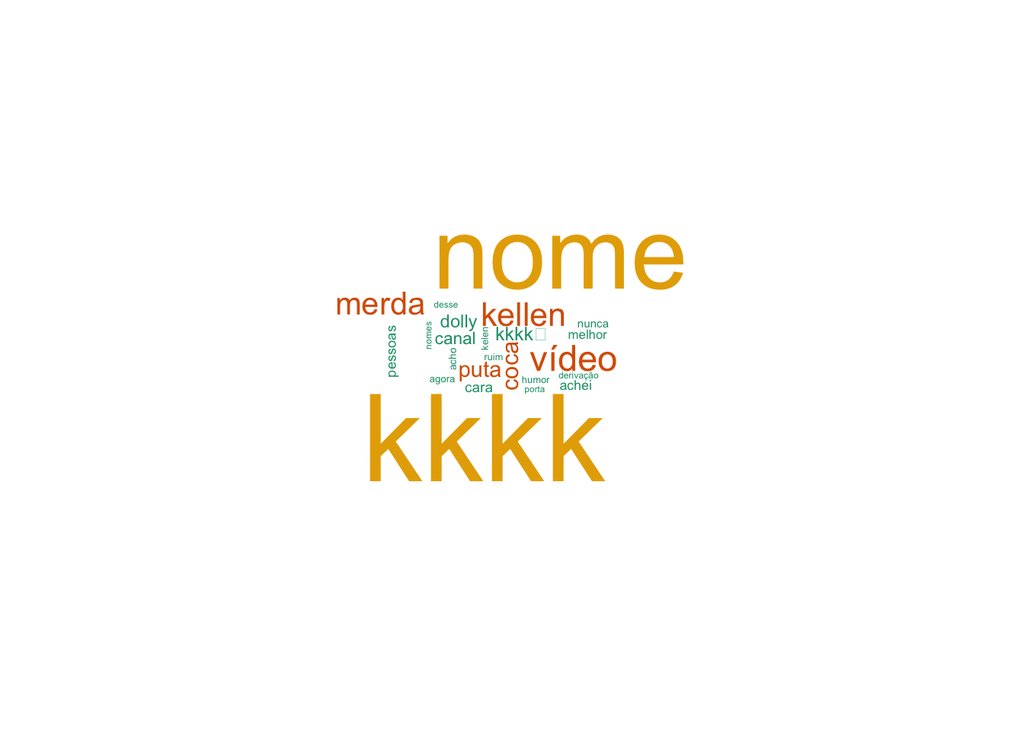

```r
set.seed(142)
wordcloud(names(freq), freq, min.freq=150, scale=c(5, .1), colors=brewer.pal(6, "Dark2"))
```

Plot the 100 most frequently occurring words.

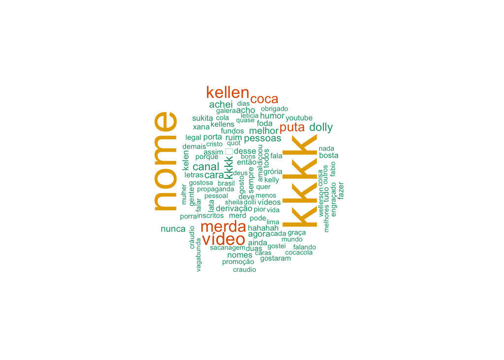

```r
set.seed(142)
dark2 <- brewer.pal(6, "Dark2")
wordcloud(names(freq), freq, max.words=100, rot.per=0.2, colors=dark2)
```

# Clustering by Term Similarity

To do this well, you should always first remove a lot of the uninteresting or infrequent words. If you have not done so already, you can remove these with the following code.

```r
dtmss <- removeSparseTerms(dtms, 0.10) # This makes a matrix that is only 10% empty space, maximum.
#inspect(dtmss)
```

# Hierarchal Clustering

First calculate distance between words & then cluster them according to similarity.

```r
library(cluster)
d <- dist(t(dtmss), method="euclidian")
fit <- hclust(d=d, method="ward")
```

```
## The "ward" method has been renamed to "ward.D"; note new "ward.D2"
```

```r
fit
```

```
##
## Call:
## hclust(d = d, method = "ward")
##
## Cluster method   : ward.D
## Distance         : euclidean
## Number of objects: 9370
```

```r
#plot(fit, hang=-1)
```

# Helping to Read a Dendrogram

```r
#plot.new()
#plot(fit, hang=-1)
#groups <- cutree(fit, k=5)   # "k=" defines the number of clusters you are using
#rect.hclust(fit, k=5, border="red") # draw dendogram with red borders around the 5 clusters
```

# K-means clustering

The k-means clustering method will attempt to cluster words into a specified number of groups (in this case 2), such that the sum of squared distances between individual words and one of the group centers. You can change the number of groups you seek by changing the number specified within the kmeans() command.

```r
#library(fpc)
#d <- dist(t(dtmss), method="euclidian")
#kfit <- kmeans(d, 2)
#kfit
#clusplot(as.matrix(d), kfit$cluster, color=T, shade=T, labels=2, lines=0)
```

# Saving objects

```r
save.image("~/Porta Text Mining/Untitled.RData")
```